# Pertemuan 1 - Pemulusan

Dewi Kunthi Siswati Suryo

2023-09-04

## Library / Packages

```r
library("forecast")
```

```r
library("graphics")
library("TTR")
library("TSA")
```

## Impor Data

```r
library(rio)
data <- import("https://raw.githubusercontent.com/dewidesis/MPDW-Prak/main/Pertemuan%201/Microsoft%20Stock%20Market%20Analysis.csv")
```

## Eksplorasi Data

Melihat data menggunakan fungsi `View()`, struktur data menggunakan fungsi `str()`, dan dimensi data menggunakan fungsi `dim()`.

```r
View(data)
str(data)
```

```
## 'data.frame':    431 obs. of  2 variables:
##  $ Date: chr  "04/01/2021" "05/01/2021" "06/01/2021" "07/01/2021" ...
##  $ Open: num  223 217 212 214 219 ...
```

```r
dim(data)
```

```
## [1] 431   2
```

Mengubah data agar terbaca sebagai data deret waktu dengan fungsi `ts()` .

```r
data.ts <- ts(data$Open)
```

Menampilkan ringkasan data

```r
summary(data.ts)
```

```
##    Min. 1st Qu.  Median    Mean 3rd Qu.    Max.
##   212.2   254.1   278.9   277.9   299.9   344.6
```

Membuat plot data deret waktu

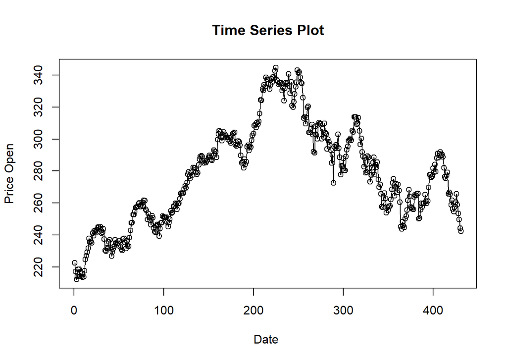

```r
ts.plot(data.ts, xlab="Date ", ylab="Price Open",
        main = "Time Series Plot")
points(data.ts)
```

## Single Moving Average & Double Moving Average

### Pembagian Data

Pembagian data latih dan data uji dilakukan dengan perbandingan 80% data latih dan 20% data uji.

```r
#membagi data latih dan data uji
training_ma <- data[1:344,]
testing_ma <- data[345:431,]
train_ma.ts <- ts(training_ma$Open)
test_ma.ts <- ts(testing_ma$Open)
```

### Eksplorasi Data

Eksplorasi data dilakukan pada keseluruhan data, data latih serta data uji menggunakan plot data deret waktu.

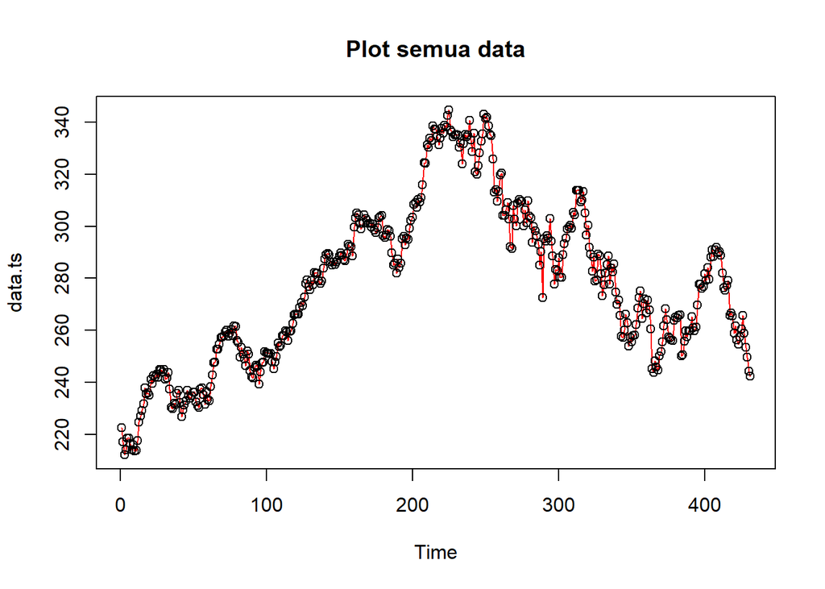

```r
#eksplorasi keseluruhan data
plot(data.ts, col="red",main="Plot semua data")
points(data.ts)
```

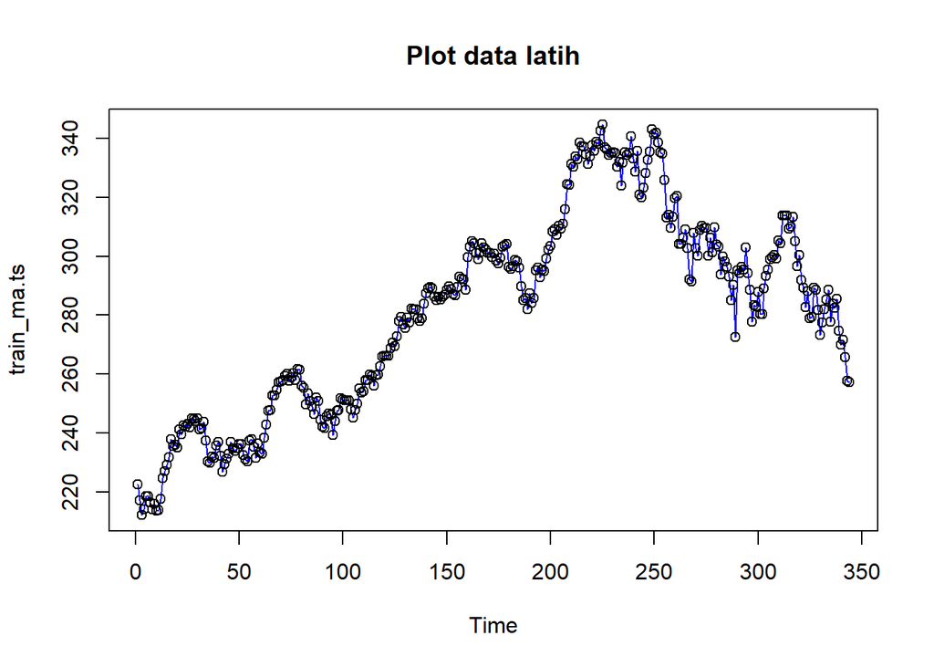

```r
#eksplorasi data latih
plot(train_ma.ts, col="blue",main="Plot data latih")
points(train_ma.ts)
```

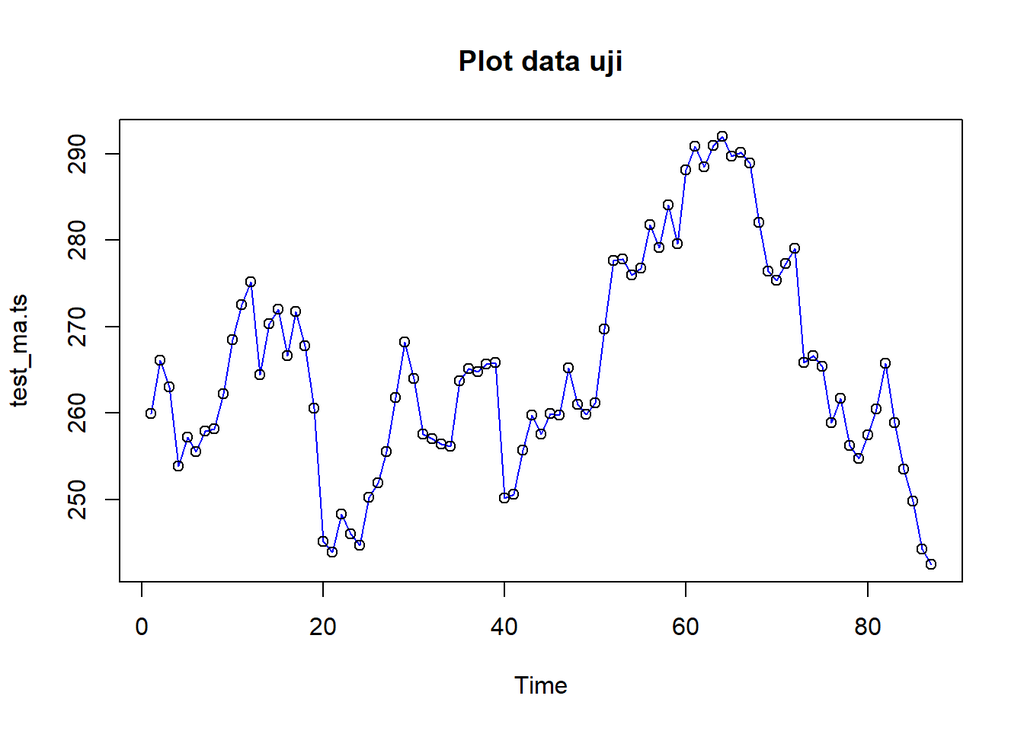

```r
#eksplorasi data uji
plot(test_ma.ts, col="blue",main="Plot data uji")
points(test_ma.ts)
```

### Single Moving Average (SMA)

Ide dasar dari Single Moving Average (SMA) adalah data suatu periode dipengaruhi oleh data periode sebelumnya. Metode pemulusan ini cocok digunakan untuk pola data stasioner atau konstan. Prinsip dasar metode pemulusan ini adalah data pemulusan pada periode ke-t merupakan rata rata dari m buah data pada periode ke-t hingga periode ke (t-m+1). Data pemulusan pada periode ke-t selanjutnya digunakan sebagai nilai peramalan pada periode ke t+1

Pemulusan menggunakan metode SMA dilakukan dengan fungsi `SMA()`. Dalam hal ini akan dilakukan pemulusan dengan parameter `m=4`.

```r
data.sma<-SMA(train_ma.ts, n=4)
data.sma
```

```
## Time Series:
## Start = 1
## End = 344
## Frequency = 1
##   [1]       NA       NA       NA 216.5000 215.5375 215.8400 216.9225 216.9175
##   [9] 216.2250 214.9875 214.3000 215.2200 217.4175 220.8075 224.6500 228.1900
##  [17] 231.5150 233.6475 235.3650 236.1650 236.9900 237.9800 239.6475 241.4400
##  [25] 241.9025 242.4775 243.0625 243.7000 243.8950 244.6850 243.7650 243.0200
##  [33] 242.9750 241.0725 238.3250 235.3775 232.4600 230.9875 232.3800 234.1300
##  [41] 234.1500 232.9525 231.3575 229.9475 230.1275 232.6925 234.0525 234.7125
##  [49] 235.2325 235.0525 235.3500 234.9875 234.0025 232.5000 232.8350 234.1575
##  [57] 235.2275 235.5475 235.3225 234.2425 233.6450 235.3750 236.9175 240.4375
##  [65] 244.1625 247.7375 250.2650 252.0400 254.4025 255.5800 256.8450 258.0350
##  [73] 258.7675 258.8525 259.1050 259.2900 258.7125 259.6725 260.3325 259.3000
##  [81] 258.6950 255.7150 253.6700 252.3925 250.7925 249.9700 249.6575 249.6325
```

[output cut: 32 more lines]

Data pemulusan pada periode ke-t selanjutnya digunakan sebagai nilai peramalan pada periode ke t+1 sehingga hasil peramalan 1 periode kedepan adalah sebagai berikut.

```r
data.ramal<-c(NA,data.sma)
data.ramal #forecast 1 periode ke depan
```

```
##   [1]       NA       NA       NA       NA 216.5000 215.5375 215.8400 216.9225
##   [9] 216.9175 216.2250 214.9875 214.3000 215.2200 217.4175 220.8075 224.6500
##  [17] 228.1900 231.5150 233.6475 235.3650 236.1650 236.9900 237.9800 239.6475
##  [25] 241.4400 241.9025 242.4775 243.0625 243.7000 243.8950 244.6850 243.7650
##  [33] 243.0200 242.9750 241.0725 238.3250 235.3775 232.4600 230.9875 232.3800
##  [41] 234.1300 234.1500 232.9525 231.3575 229.9475 230.1275 232.6925 234.0525
##  [49] 234.7125 235.2325 235.0525 235.3500 234.9875 234.0025 232.5000 232.8350
##  [57] 234.1575 235.2275 235.5475 235.3225 234.2425 233.6450 235.3750 236.9175
##  [65] 240.4375 244.1625 247.7375 250.2650 252.0400 254.4025 255.5800 256.8450
##  [73] 258.0350 258.7675 258.8525 259.1050 259.2900 258.7125 259.6725 260.3325
##  [81] 259.3000 258.6950 255.7150 253.6700 252.3925 250.7925 249.9700 249.6575
##  [89] 249.6325 248.5050 247.4350 244.8475 243.5250 244.0250 245.0500 244.4275
##  [97] 244.0225 244.2775 244.6575 247.7725 249.6400 250.5400 251.3425 251.2075
## [105] 250.3825 248.8950 248.0850 247.7725 249.5300 251.6775 253.3100 255.3125
## [113] 255.9975 257.4875 258.7650 258.2850 258.7175 258.7300 259.5600 262.0400
```

[output cut: 29 more lines]

Selanjutnya akan dilakukan peramalan sejumlah data uji yaitu 87 periode. Pada metode SMA, hasil peramalan 87 periode ke depan akan bernilai sama dengan hasil peramalan 1 periode kedepan. Dalam hal ini akan dilakukan pengguabungan data aktual train, data hasil pemulusan dan data hasil ramalan 87 periode kedepan.

```r
data.gab<-cbind(aktual=c(train_ma.ts,rep(NA,87)),pemulusan=c(data.sma,rep(NA,87)),ramalan=c(data.ramal,rep(data.ramal[length(data.ramal)],86)))
data.gab #forecast 87 periode ke depan
```

```
##        aktual pemulusan  ramalan
##   [1,] 222.53        NA       NA
##   [2,] 217.26        NA       NA
##   [3,] 212.17        NA       NA
##   [4,] 214.04  216.5000       NA
##   [5,] 218.68  215.5375 216.5000
##   [6,] 218.47  215.8400 215.5375
##   [7,] 216.50  216.9225 215.8400
##   [8,] 214.02  216.9175 216.9225
##   [9,] 215.91  216.2250 216.9175
##  [10,] 213.52  214.9875 216.2250
##  [11,] 213.75  214.3000 214.9875
##  [12,] 217.70  215.2200 214.3000
##  [13,] 224.70  217.4175 215.2200
##  [14,] 227.08  220.8075 217.4175
```

[output cut: 417 more lines]

Adapun plot data deret waktu dari hasil peramalan yang dilakukan adalah sebagai berikut.

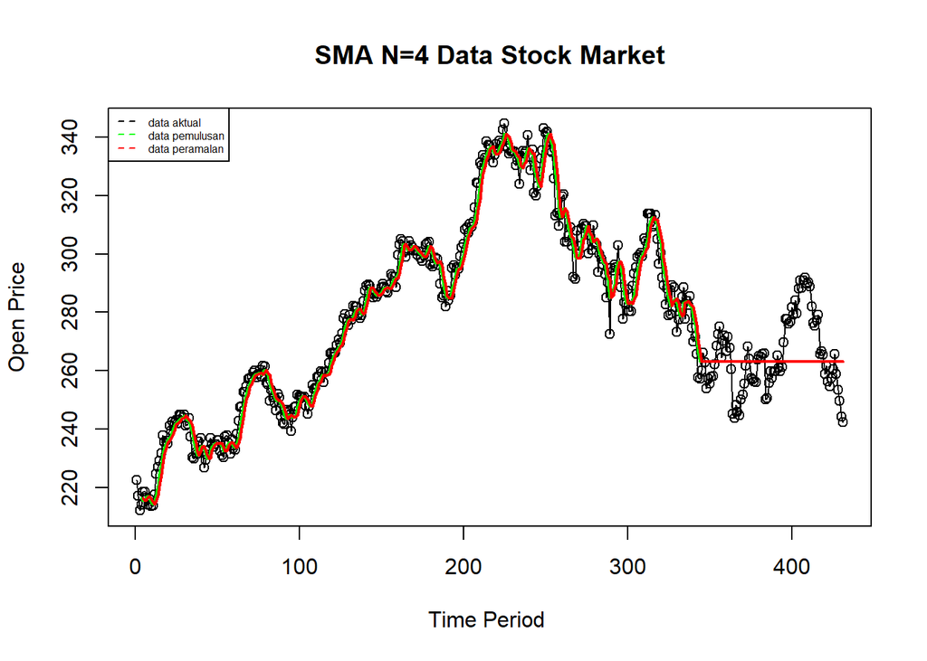

```r
ts.plot(data.ts, xlab="Time Period ", ylab="Open Price", main= "SMA N=4 Data Stock Market")
points(data.ts)
lines(data.gab[,2],col="green",lwd=2)
lines(data.gab[,3],col="red",lwd=2)
legend("topleft",c("data aktual","data pemulusan","data peramalan"), lty=8, col=c("black","green","red"), cex=0.5)
```

Selanjutnya perhitungan akurasi dilakukan dengan ukuran akurasi *Sum Squares Error* (SSE), *Mean Square Error* (MSE) dan *Mean Absolute Percentage Error* (MAPE). Perhitungan akurasi dilakukan baik pada data latih maupun pada data uji.

```r
#Menghitung nilai keakuratan data latih
error_train.sma = train_ma.ts-data.ramal[1:length(train_ma.ts)]
SSE_train.sma = sum(error_train.sma[5:length(train_ma.ts)]^2)
MSE_train.sma = mean(error_train.sma[5:length(train_ma.ts)]^2)
MAPE_train.sma = mean(abs((error_train.sma[5:length(train_ma.ts)]/train_ma.ts[5:length(train_ma.ts)])*100))

akurasi_train.sma <- matrix(c(SSE_train.sma, MSE_train.sma, MAPE_train.sma))
row.names(akurasi_train.sma)<- c("SSE", "MSE", "MAPE")
colnames(akurasi_train.sma) <- c("Akurasi m = 4")
akurasi_train.sma
```

```
##      Akurasi m = 4
## SSE   11358.417924
## MSE      33.407112
## MAPE      1.619152
```

Dalam hal ini nilai MAPE data latih pada metode pemulusan SMA kurang dari 2%, nilai ini dapat dikategorikan sebagai nilai akurasi yang sangat baik. Selanjutnya dilakukan perhitungan nilai MAPE data uji pada metode pemulusan SMA.

```r
#Menghitung nilai keakuratan data uji
error_test.sma = test_ma.ts-data.gab[345:431,3]
SSE_test.sma = sum(error_test.sma^2)
MSE_test.sma = mean(error_test.sma^2)
MAPE_test.sma = mean(abs((error_test.sma/test_ma.ts*100)))

akurasi_test.sma <- matrix(c(SSE_test.sma, MSE_test.sma, MAPE_test.sma))
row.names(akurasi_test.sma)<- c("SSE", "MSE", "MAPE")
colnames(akurasi_test.sma) <- c("Akurasi m = 4")
akurasi_test.sma
```

```
##      Akurasi m = 4
## SSE   13662.743438
## MSE     157.043028
## MAPE      3.652428
```

Perhitungan akurasi menggunakan data uji menghasilkan nilai MAPE yang kurang dari 5% sehingga nilai akurasi ini dapat dikategorikan sebagai sangat baik.

### Double Moving Average (DMA)

Metode pemulusan Double Moving Average (DMA) pada dasarnya mirip dengan SMA. Namun demikian, metode ini lebih cocok digunakan untuk pola data trend. Proses pemulusan dengan rata rata dalam metode ini dilakukan sebanyak 2 kali.

```r
dma <- SMA(data.sma, n = 4)
At <- 2*data.sma - dma
Bt <- 2/(4-1)*(data.sma - dma)
data.dma<- At+Bt
data.ramal2<- c(NA, data.dma)

t = 1:87
f = c()

for (i in t) {
  f[i] = At[length(At)] + Bt[length(Bt)]*(i)
}

data.gab2 <- cbind(aktual = c(train_ma.ts,rep(NA,87)), pemulusan1 = c(data.sma,rep(NA,87)),pemulusan2 = c(data.dma, rep(NA,87)),At = c(At, rep(NA,87)), Bt = c(Bt,rep(NA,87)),ramalan = c(data.ramal2, f[-1]))
data.gab2
```

```
##        aktual pemulusan1 pemulusan2       At          Bt     ramalan
##   [1,] 222.53         NA         NA       NA          NA          NA
##   [2,] 217.26         NA         NA       NA          NA          NA
##   [3,] 212.17         NA         NA       NA          NA          NA
##   [4,] 214.04   216.5000         NA       NA          NA          NA
##   [5,] 218.68   215.5375         NA       NA          NA          NA
##   [6,] 218.47   215.8400         NA       NA          NA          NA
##   [7,] 216.50   216.9225   218.1267 217.6450  0.48166717          NA
##   [8,] 214.02   216.9175   217.9394 217.5306  0.40875179 218.1266647
##   [9,] 215.91   216.2250   215.8063 215.9738 -0.16749763 217.9393790
##  [10,] 213.52   214.9875   212.8615 213.7119 -0.85041492 215.8062582
##  [11,] 213.75   214.3000   212.1208 212.9925 -0.87166596 212.8614657
##  [12,] 217.70   215.2200   215.2815 215.2569  0.02458258 212.1208381
##  [13,] 224.70   217.4175   220.6446 219.3537  1.29083187 215.2814577
##  [14,] 227.08   220.8075   227.2596 224.6787  2.58083221 220.6445792
```

[output cut: 417 more lines]

Hasil pemulusan menggunakan metode DMA divisualisasikan sebagai berikut

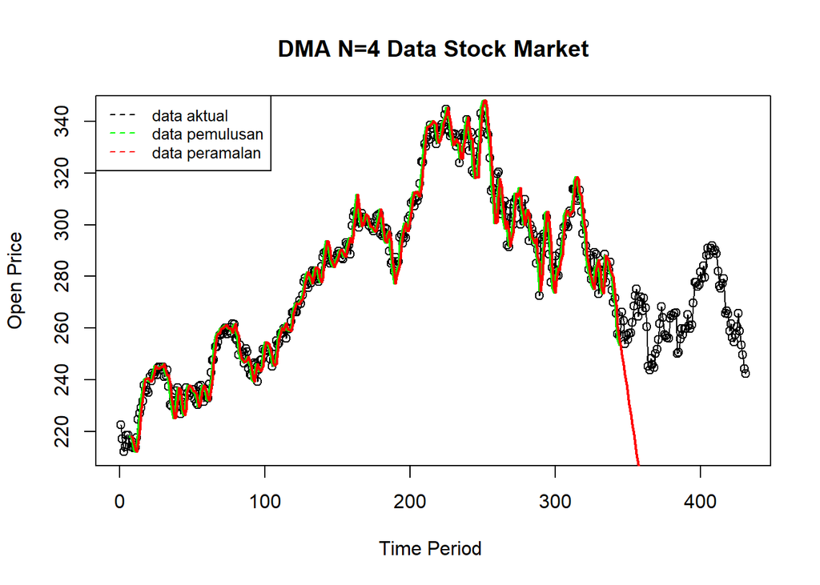

```r
ts.plot(data.ts, xlab="Time Period ", ylab="Open Price", main= "DMA N=4 Data Stock Market")
points(data.ts)
lines(data.gab2[,3],col="green",lwd=2)
lines(data.gab2[,6],col="red",lwd=2)
legend("topleft",c("data aktual","data pemulusan","data peramalan"), lty=8, col=c("black","green","red"), cex=0.8)
```

Selanjutnya perhitungan akurasi dilakukan baik pada data latih maupun data uji. Perhitungan akurasi dilakukan dengan ukuran akurasi SSE, MSE dan MAPE.

```r
#Menghitung nilai keakuratan data latih
error_train.dma = train_ma.ts-data.ramal2[1:length(train_ma.ts)]
SSE_train.dma = sum(error_train.dma[8:length(train_ma.ts)]^2)
MSE_train.dma = mean(error_train.dma[8:length(train_ma.ts)]^2)
MAPE_train.dma = mean(abs((error_train.dma[8:length(train_ma.ts)]/train_ma.ts[8:length(train_ma.ts)])*100))

akurasi_train.dma <- matrix(c(SSE_train.dma, MSE_train.dma, MAPE_train.dma))
row.names(akurasi_train.dma)<- c("SSE", "MSE", "MAPE")
colnames(akurasi_train.dma) <- c("Akurasi m = 4")
akurasi_train.dma
```

```
##      Akurasi m = 4
## SSE   11050.317373
## MSE      32.790259
## MAPE      1.557843
```

Perhitungan akurasi pada data latih menggunakan nilai MAPE menghasilkan nilai MAPE yang kurang dari 10% sehingga dikategorikan sangat baik. Selanjutnya, perhitungan nilai akurasi dilakukan pada data uji.

```r
#Menghitung nilai keakuratan data uji
error_test.dma = test_ma.ts-data.gab2[345:431,6]
SSE_test.dma = sum(error_test.dma^2)
MSE_test.dma = mean(error_test.dma^2)
MAPE_test.dma = mean(abs((error_test.dma/test_ma.ts*100)))

akurasi_test.dma <- matrix(c(SSE_test.dma, MSE_test.dma, MAPE_test.dma))
row.names(akurasi_test.dma)<- c("SSE", "MSE", "MAPE")
colnames(akurasi_test.dma) <- c("Akurasi m = 4")
akurasi_test.dma
```

```
##      Akurasi m = 4
## SSE   3.597018e+06
## MSE   4.134503e+04
## MAPE  6.626931e+01
```

Pada data latih, metode DMA lebih baik dibandingkan dengan metode SMA, sedangkan pada data uji, metode SMA lebih baik dibandingkan DMA.

## Single Exponential Smoothing & Double Exponential Smoothing

Metode *Exponential Smoothing* adalah metode pemulusan dengan melakukan pembobotan menurun secara eksponensial. Nilai yang lebih baru diberi bobot yang lebih besar dari nilai terdahulu. Terdapat satu atau lebih parameter pemulusan yang ditentukan secara eksplisit, dan hasil pemilihan parameter tersebut akan menentukan bobot yang akan diberikan pada nilai pengamatan. Ada dua macam model, yaitu model tunggal dan ganda.

### Pembagian Data

Pembagian data latih dan data uji dilakukan dengan perbandingan 80% data latih dan 20% data uji.

```r
#membagi training dan testing
training<-data[1:344,]
testing<-data[345:431,]
train.ts <- ts(training$Open)
test.ts <- ts(testing$Open)
```

### Eksplorasi

Eksplorasi dilakukan dengan membuat plot data deret waktu untuk keseluruhan data, data latih, dan data uji.

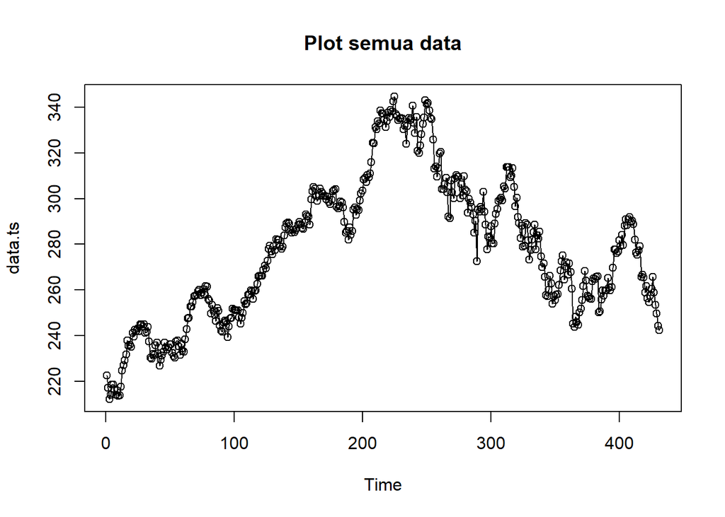

```r
#eksplorasi data
plot(data.ts, col="black",main="Plot semua data")
points(data.ts)
```

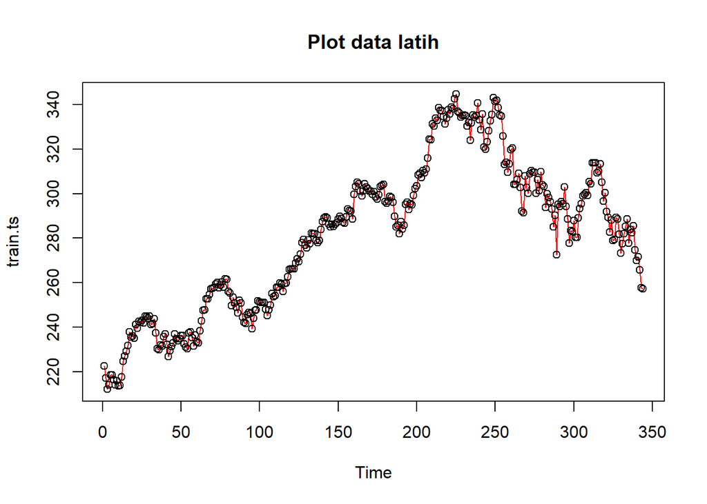

```r
plot(train.ts, col="red",main="Plot data latih")
points(train.ts)
```

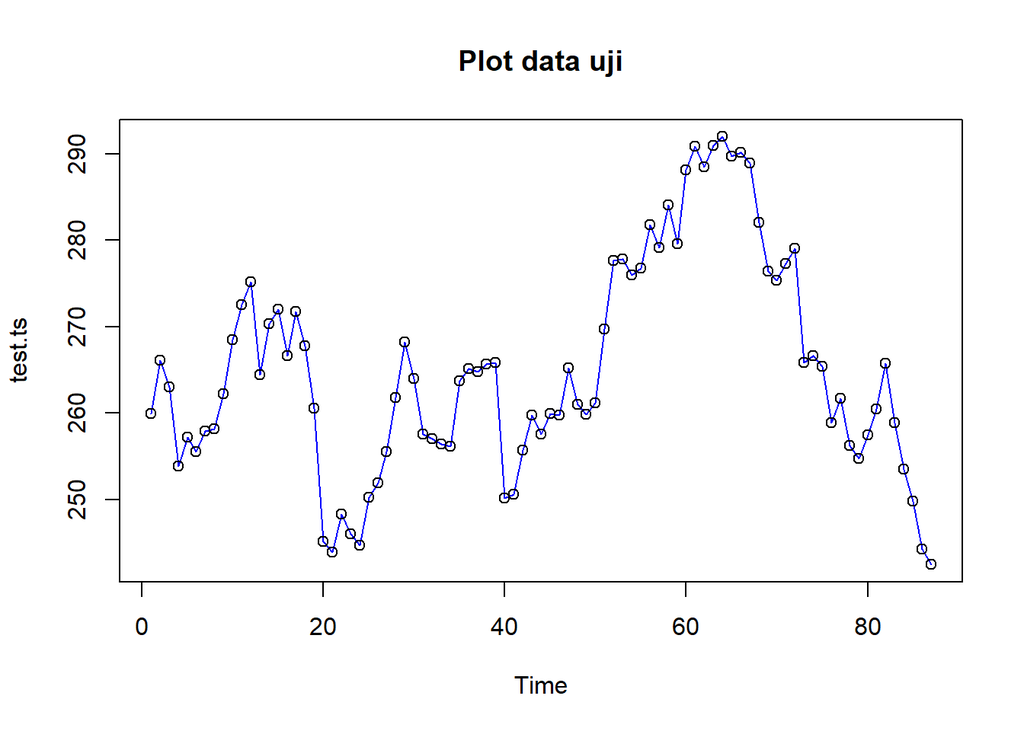

```r
plot(test.ts, col="blue",main="Plot data uji")
points(test.ts)
```

### SES

Single Exponential Smoothing merupakan metode pemulusan yang tepat digunakan untuk data dengan pola stasioner atau konstan.

Nilai pemulusan pada periode ke-t didapat dari persamaan:

$$\tilde{y}_T=\lambda y_t+(1-\lambda)\tilde{y}_{T-1}$$

Nilai parameter $\lambda$ adalah nilai antara 0 dan 1.

Nilai pemulusan periode ke-t bertindak sebagai nilai ramalan pada periode ke-$(T+\tau)$.

$$\tilde{y}_{T+\tau}(T)=\tilde{y}_T$$

Pemulusan dengan metode SES dapat dilakukan dengan dua fungsi dari *packages* berbeda, yaitu (1) fungsi `ses()` dari *packages* `forecast` dan (2) fungsi `HoltWinters` dari *packages* `stats` .

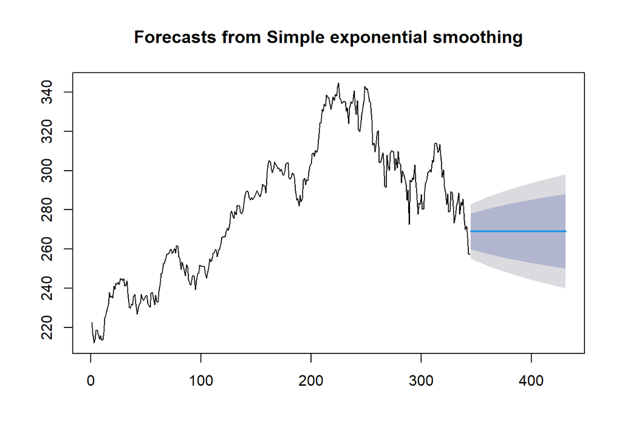

```r
#Cara 1 (fungsi ses)
ses.1 <- ses(train.ts, h = 87, alpha = 0.2)
plot(ses.1)
```

```r
ses.1
```

```
##     Point Forecast    Lo 80    Hi 80    Lo 95    Hi 95
## 345       269.0135 260.0151 278.0120 255.2517 282.7754
## 346       269.0135 259.8369 278.1902 254.9791 283.0480
## 347       269.0135 259.6621 278.3650 254.7118 283.3153
## 348       269.0135 259.4905 278.5366 254.4493 283.5777
## 349       269.0135 259.3220 278.7051 254.1915 283.8355
## 350       269.0135 259.1563 278.8708 253.9382 284.0889
## 351       269.0135 258.9933 279.0337 253.6890 284.3381
## 352       269.0135 258.8330 279.1941 253.4438 284.5833
## 353       269.0135 258.6752 279.3519 253.2024 284.8247
## 354       269.0135 258.5197 279.5074 252.9646 285.0625
## 355       269.0135 258.3665 279.6606 252.7303 285.2968
## 356       269.0135 258.2155 279.8116 252.4993 285.5278
## 357       269.0135 258.0665 279.9606 252.2715 285.7556
## 358       269.0135 257.9196 280.1075 252.0468 285.9803
```

[output cut: 73 more lines]

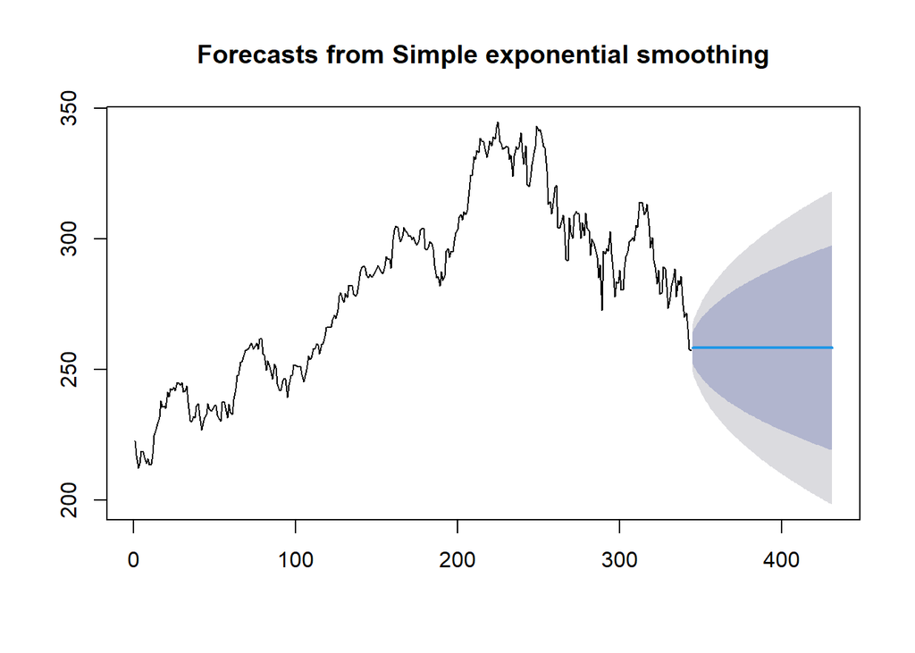

```r
ses.2<- ses(train.ts, h = 87, alpha = 0.7)
plot(ses.2)
```

```r
ses.2
```

```
##     Point Forecast    Lo 80    Hi 80    Lo 95    Hi 95
## 345       258.3389 252.3707 264.3072 249.2113 267.4666
## 346       258.3389 251.0537 265.6241 247.1972 269.4806
## 347       258.3389 249.9408 266.7370 245.4952 271.1826
## 348       258.3389 248.9591 267.7187 243.9937 272.6841
## 349       258.3389 248.0708 268.6071 242.6351 274.0427
## 350       258.3389 247.2534 269.4244 241.3851 275.2928
## 351       258.3389 246.4923 270.1855 240.2211 276.4568
## 352       258.3389 245.7772 270.9006 239.1274 277.5504
## 353       258.3389 245.1007 271.5771 238.0928 278.5850
## 354       258.3389 244.4571 272.2207 237.1086 279.5693
## 355       258.3389 243.8421 272.8357 236.1679 280.5099
## 356       258.3389 243.2521 273.4257 235.2656 281.4122
## 357       258.3389 242.6843 273.9935 234.3973 282.2805
## 358       258.3389 242.1365 274.5414 233.5594 283.1184
```

[output cut: 73 more lines]

Untuk mendapatkan gambar hasil pemulusan pada data latih dengan fungsi `ses()` , perlu digunakan fungsi `autoplot()` dan `autolayer()` dari *library packages* `ggplot2` .

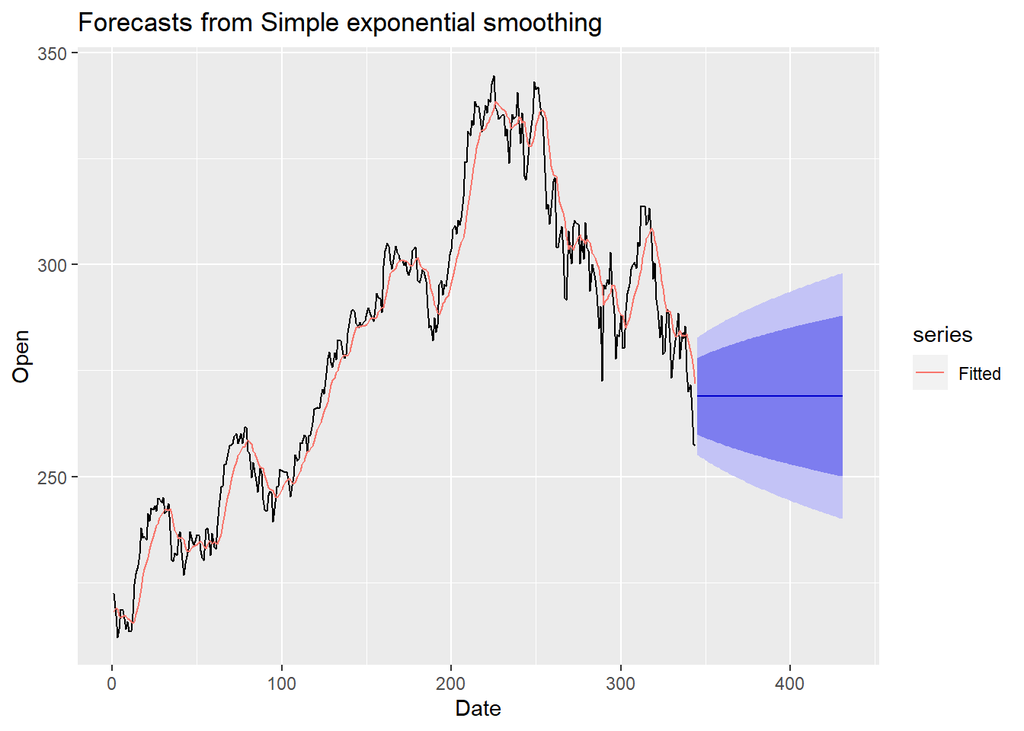

```r
library(ggplot2)
autoplot(ses.1) +
  autolayer(fitted(ses.1), series="Fitted") +
  ylab("Open") + xlab("Date")
```

Pada fungsi `ses()` , terdapat beberapa argumen yang umum digunakan, yaitu nilai `y` , `gamma` , `beta` , `alpha` , dan `h` .

Nilai `y` adalah nilai data deret waktu, `gamma` adalah parameter pemulusan untuk komponen musiman, `beta` adalah parameter pemulusan untuk tren, dan `alpha` adalah parameter pemulusan untuk stasioner, serta `h` adalah banyaknya periode yang akan diramalkan.

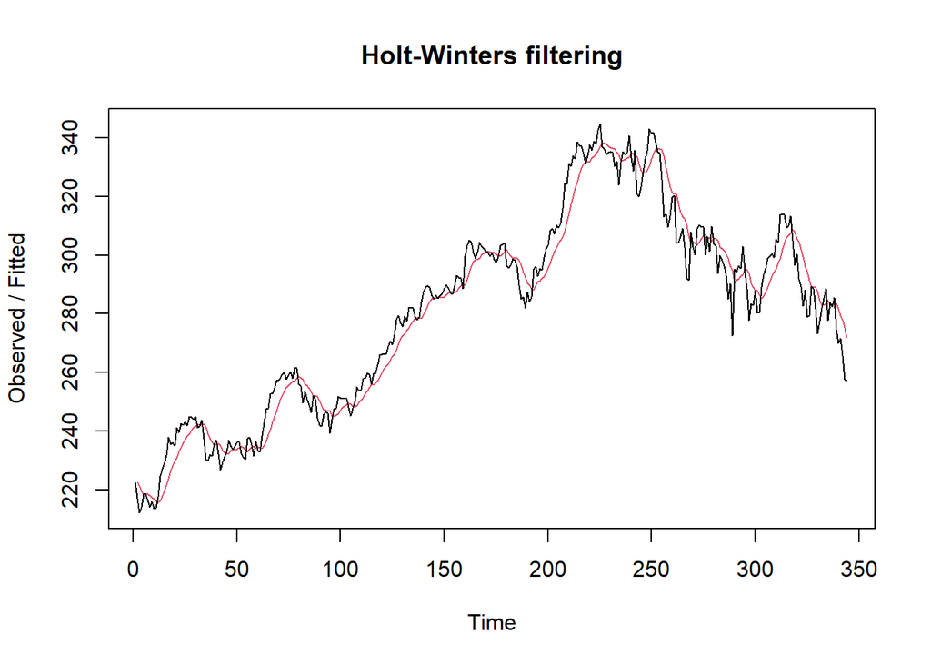

```r
#Cara 2 (fungsi Holtwinter)
ses1<- HoltWinters(train.ts, gamma = FALSE, beta = FALSE, alpha = 0.2)
plot(ses1)
```

```r
#ramalan
ramalan1<- forecast(ses1, h=87)
ramalan1
```

```
##     Point Forecast    Lo 80    Hi 80    Lo 95    Hi 95
## 345       269.0135 260.0430 277.9841 255.2943 282.7328
## 346       269.0135 259.8654 278.1617 255.0226 283.0045
## 347       269.0135 259.6911 278.3360 254.7561 283.2710
## 348       269.0135 259.5200 278.5071 254.4945 283.5326
## 349       269.0135 259.3520 278.6751 254.2375 283.7896
## 350       269.0135 259.1868 278.8403 253.9849 284.0422
## 351       269.0135 259.0244 279.0027 253.7364 284.2906
## 352       269.0135 258.8646 279.1625 253.4920 284.5351
## 353       269.0135 258.7072 279.3199 253.2513 284.7757
## 354       269.0135 258.5522 279.4749 253.0143 285.0128
## 355       269.0135 258.3995 279.6276 252.7807 285.2464
## 356       269.0135 258.2489 279.7782 252.5505 285.4766
## 357       269.0135 258.1004 279.9267 252.3234 285.7037
## 358       269.0135 257.9539 280.0732 252.0993 285.9278
```

[output cut: 73 more lines]

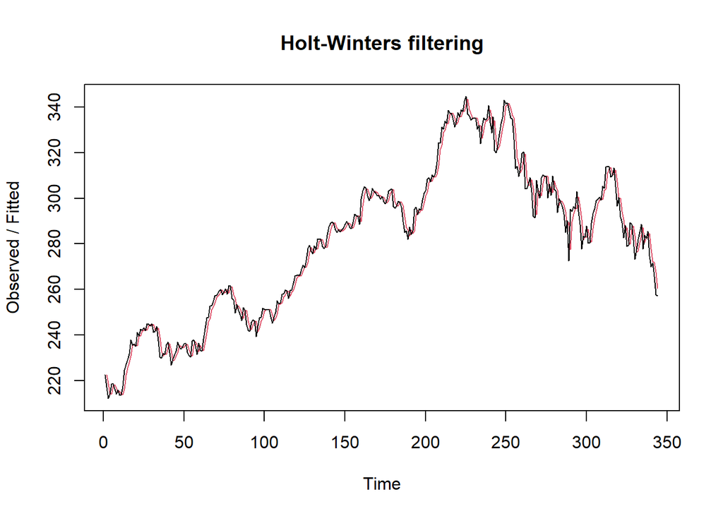

```r
ses2<- HoltWinters(train.ts, gamma = FALSE, beta = FALSE, alpha = 0.7)
plot(ses2)
```

```r
#ramalan
ramalan2<- forecast(ses2, h=87)
ramalan2
```

```
##     Point Forecast    Lo 80    Hi 80    Lo 95    Hi 95
## 345       258.3389 252.3721 264.3058 249.2134 267.4644
## 346       258.3389 251.0554 265.6224 247.1998 269.4780
## 347       258.3389 249.9428 266.7350 245.4982 271.1797
## 348       258.3389 248.9613 267.7166 243.9970 272.6808
## 349       258.3389 248.0731 268.6047 242.6388 274.0391
## 350       258.3389 247.2560 269.4219 241.3890 275.2888
## 351       258.3389 246.4950 270.1828 240.2253 276.4526
## 352       258.3389 245.7801 270.8977 239.1319 277.5459
## 353       258.3389 245.1038 271.5741 238.0975 278.5803
## 354       258.3389 244.4603 272.2175 237.1135 279.5644
## 355       258.3389 243.8455 272.8324 236.1731 280.5047
## 356       258.3389 243.2556 273.4222 235.2710 281.4068
## 357       258.3389 242.6880 273.9898 234.4029 282.2750
## 358       258.3389 242.1402 274.5376 233.5652 283.1127
```

[output cut: 73 more lines]

Fungsi `HoltWinters` memiliki argumen yang sama dengan fungsi `ses()` . Argumen-argumen kedua fungsi dapat dilihat lebih lanjut dengan `?ses()` atau `?HoltWinters` .

Nilai parameter $\alpha$ dari kedua fungsi dapat dioptimalkan menyesuaikan dari *error*-nya paling minimumnya. Caranya adalah dengan membuat parameter $\alpha =$ `NULL` .

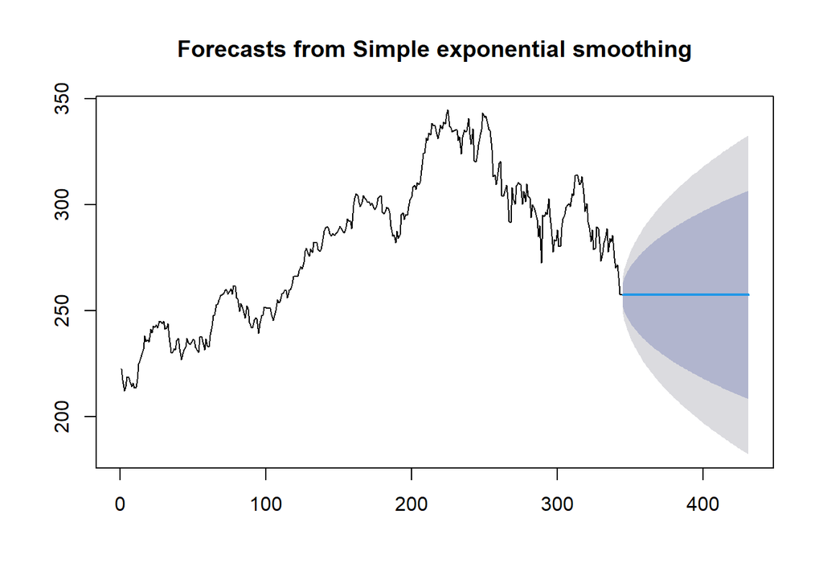

```r
#SES
ses.opt <- ses(train.ts, h = 87, alpha = NULL)
plot(ses.opt)
```

```r
ses.opt
```

```
##     Point Forecast    Lo 80    Hi 80    Lo 95    Hi 95
## 345       257.4673 251.6246 263.3100 248.5317 266.4029
## 346       257.4673 249.6020 265.3325 245.4384 269.4961
## 347       257.4673 248.0023 266.9323 242.9918 271.9428
## 348       257.4673 246.6362 268.2983 240.9026 274.0320
## 349       257.4673 245.4242 269.5104 239.0489 275.8856
## 350       257.4673 244.3234 270.6112 237.3655 277.5691
## 351       257.4673 243.3080 271.6266 235.8125 279.1221
## 352       257.4673 242.3606 272.5739 234.3636 280.5709
## 353       257.4673 241.4693 273.4653 233.0004 281.9341
## 354       257.4673 240.6250 274.3095 231.7093 283.2253
## 355       257.4673 239.8212 275.1134 230.4799 284.4547
## 356       257.4673 239.0523 275.8822 229.3040 285.6305
## 357       257.4673 238.3143 276.6202 228.1754 286.7592
## 358       257.4673 237.6037 277.3308 227.0886 287.8460
```

[output cut: 73 more lines]

```r
#Lamda Optimum Holt Winter
sesopt<- HoltWinters(train.ts, gamma = FALSE, beta = FALSE,alpha = NULL)
sesopt
```

```
## Holt-Winters exponential smoothing without trend and without seasonal component.
##
## Call:
## HoltWinters(x = train.ts, alpha = NULL, beta = FALSE, gamma = FALSE)
##
## Smoothing parameters:
##  alpha: 0.901787
##  beta : FALSE
##  gamma: FALSE
##
## Coefficients:
##       [,1]
## a 257.4661
```

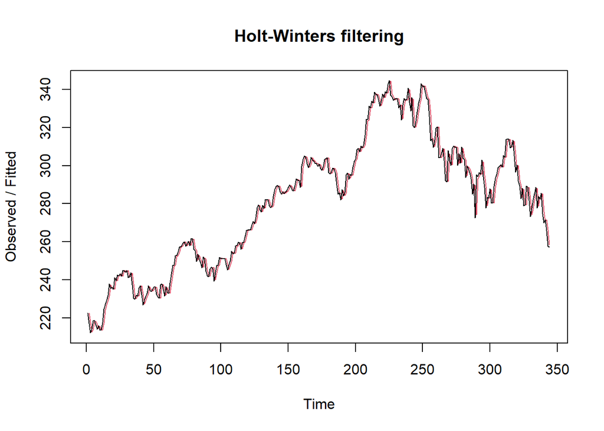

```r
plot(sesopt)
```

```r
#ramalan
ramalanopt<- forecast(sesopt, h=87)
ramalanopt
```

```
##     Point Forecast    Lo 80    Hi 80    Lo 95    Hi 95
## 345       257.4661 251.6250 263.3071 248.5330 266.3991
## 346       257.4661 249.6008 265.3314 245.4371 269.4950
## 347       257.4661 247.9999 266.9322 242.9888 271.9433
## 348       257.4661 246.6331 268.2990 240.8985 274.0336
## 349       257.4661 245.4204 269.5117 239.0438 275.8883
## 350       257.4661 244.3191 270.6130 237.3595 277.5726
## 351       257.4661 243.3031 271.6290 235.8057 279.1264
## 352       257.4661 242.3554 272.5768 234.3562 280.5759
## 353       257.4661 241.4636 273.4685 232.9924 281.9397
## 354       257.4661 240.6190 274.3131 231.7007 283.2314
## 355       257.4661 239.8147 275.1174 230.4707 284.4614
## 356       257.4661 239.0456 275.8865 229.2944 285.6378
## 357       257.4661 238.3073 276.6249 228.1652 286.7669
## 358       257.4661 237.5964 277.3357 227.0780 287.8541
```

[output cut: 73 more lines]

Setelah dilakukan peramalan, akan dilakukan perhitungan keakuratan hasil peramalan. Perhitungan akurasi ini dilakukan baik pada data latih dan data uji.

#### Akurasi Data Latih

Perhitungan akurasi data dapat dilakukan dengan cara langsung maupun manual. Secara langsung, nilai akurasi dapat diambil dari objek yang tersimpan pada hasil SES, yaitu *sum of squared errors* (SSE). Nilai akurasi lain dapat dihitung pula dari nilai SSE tersebut.

```r
#Keakuratan Metode
#Pada data training
SSE1<-ses1$SSE
MSE1<-ses1$SSE/length(train.ts)
RMSE1<-sqrt(MSE1)

akurasi1 <- matrix(c(SSE1,MSE1,RMSE1))
row.names(akurasi1)<- c("SSE", "MSE", "RMSE")
colnames(akurasi1) <- c("Akurasi lamda=0.2")
akurasi1
```

```
##      Akurasi lamda=0.2
## SSE       16914.235898
## MSE          49.169290
## RMSE          7.012082
```

```r
SSE2<-ses2$SSE
MSE2<-ses2$SSE/length(train.ts)
RMSE2<-sqrt(MSE2)

akurasi2 <- matrix(c(SSE2,MSE2,RMSE2))
row.names(akurasi2)<- c("SSE", "MSE", "RMSE")
colnames(akurasi2) <- c("Akurasi lamda=0.7")
akurasi2
```

```
##      Akurasi lamda=0.7
## SSE        7421.519190
## MSE          21.574184
## RMSE          4.644802
```

```r
#Cara Manual
fitted1<-ramalan1$fitted
sisaan1<-ramalan1$residuals
head(sisaan1)
```

```
## Time Series:
## Start = 1
## End = 6
## Frequency = 1
## [1]         NA -5.2700040 -9.3060002 -5.5748052  0.1801559 -0.0658673
```

```r
resid1<-training$Open-ramalan1$fitted
head(resid1)
```

```
## Time Series:
## Start = 1
## End = 6
## Frequency = 1
## [1]         NA -5.2700040 -9.3060002 -5.5748052  0.1801559 -0.0658673
```

```r
#Cara Manual
SSE.1=sum(sisaan1[2:length(train.ts)]^2)
SSE.1
```

```
## [1] 16914.24
```

```r
MSE.1 = SSE.1/length(train.ts)
MSE.1
```

```
## [1] 49.16929
```

```r
MAPE.1 = sum(abs(sisaan1[2:length(train.ts)]/train.ts[2:length(train.ts)])*
               100)/length(train.ts)
MAPE.1
```

```
## [1] 1.984247
```

```r
akurasi.1 <- matrix(c(SSE.1,MSE.1,MAPE.1))
row.names(akurasi.1)<- c("SSE", "MSE", "MAPE")
colnames(akurasi.1) <- c("Akurasi lamda=0.2")
akurasi.1
```

```
##      Akurasi lamda=0.2
## SSE       16914.235898
## MSE          49.169290
## MAPE          1.984247
```

```r
fitted2<-ramalan2$fitted
sisaan2<-ramalan2$residuals
head(sisaan2)
```

```
## Time Series:
## Start = 1
## End = 6
## Frequency = 1
## [1]         NA -5.2700040 -6.6709982 -0.1313045  4.6006087  1.1701906
```

```r
resid2<-training$Open-ramalan2$fitted
head(resid2)
```

```
## Time Series:
## Start = 1
## End = 6
## Frequency = 1
## [1]         NA -5.2700040 -6.6709982 -0.1313045  4.6006087  1.1701906
```

```r
SSE.2=sum(sisaan2[2:length(train.ts)]^2)
SSE.2
```

```
## [1] 7421.519
```

```r
MSE.2 = SSE.2/length(train.ts)
MSE.2
```

```
## [1] 21.57418
```

```r
MAPE.2 = sum(abs(sisaan2[2:length(train.ts)]/train.ts[2:length(train.ts)])*
               100)/length(train.ts)
MAPE.2
```

```
## [1] 1.228993
```

```r
akurasi.2 <- matrix(c(SSE.2,MSE.2,MAPE.2))
row.names(akurasi.2)<- c("SSE", "MSE", "MAPE")
colnames(akurasi.2) <- c("Akurasi lamda=0.7")
akurasi.2
```

```
##      Akurasi lamda=0.7
## SSE        7421.519190
## MSE          21.574184
## MAPE          1.228993
```

Berdasarkan nilai SSE, MSE, RMSE, dan MAPE di antara kedua parameter, nilai parameter $\lambda=0,7$ menghasilkan akurasi yang lebih baik dibanding $\lambda=0,2$ . Hal ini dilihat dari nilai masing-masing ukuran akurasi yang lebih kecil. Berdasarkan nilai MAPE-nya, hasil ini dapat dikategorikan sebagai peramalan sangat baik.

#### Akurasi Data Uji

Akurasi data uji dapat dihitung dengan cara yang hampir sama dengan perhitungan akurasi data latih.

```r
selisih1<-ramalan1$mean-testing$Open
SSEtesting1<-sum(selisih1^2)
MSEtesting1<-SSEtesting1/length(testing)

selisih2<-ramalan2$mean-testing$Open
SSEtesting2<-sum(selisih2^2)
MSEtesting2<-SSEtesting2/length(testing)

selisihopt<-ramalanopt$mean-testing$Open
SSEtestingopt<-sum(selisihopt^2)
MSEtestingopt<-SSEtestingopt/length(testing)

akurasitesting1 <- matrix(c(SSEtesting1,SSEtesting2,SSEtestingopt))
row.names(akurasitesting1)<- c("SSE1", "SSE2", "SSEopt")
akurasitesting1
```

```
##            [,1]
## SSE1   14562.62
## SSE2   17361.46
## SSEopt 18467.22
```

```r
akurasitesting2 <- matrix(c(MSEtesting1,MSEtesting2,MSEtestingopt))
row.names(akurasitesting2)<- c("MSE1", "MSE2", "MSEopt")
akurasitesting2
```

```
##            [,1]
## MSE1   7281.308
## MSE2   8680.732
## MSEopt 9233.608
```

```r
#cara lain
accuracy(ramalanopt,testing$Open)
```

```
##                     ME      RMSE       MAE        MPE     MAPE     MASE
## Training set 0.1129473  4.552532  3.310935 0.03313016 1.176686 1.004645
## Test set     7.7170412 14.569380 10.990591 2.70236714 4.025011 3.334902
##                     ACF1
## Training set -0.00110646
## Test set              NA
```

### DES

Metode pemulusan *Double Exponential Smoothing* (DES) digunakan untuk data yang memiliki pola tren. Metode DES adalah metode semacam SES, hanya saja dilakukan dua kali, yaitu pertama untuk tahapan ‘level’ dan kedua untuk tahapan ‘tren’. Pemulusan menggunakan metode ini akan menghasilkan peramalan tidak konstan untuk periode berikutnya.

Pemulusan dengan metode DES kali ini akan menggunakan fungsi `HoltWinters()` . Jika sebelumnya nilai argumen `beta` dibuat `FALSE` , kali ini argumen tersebut akan diinisialisasi bersamaan dengan nilai `alpha` .

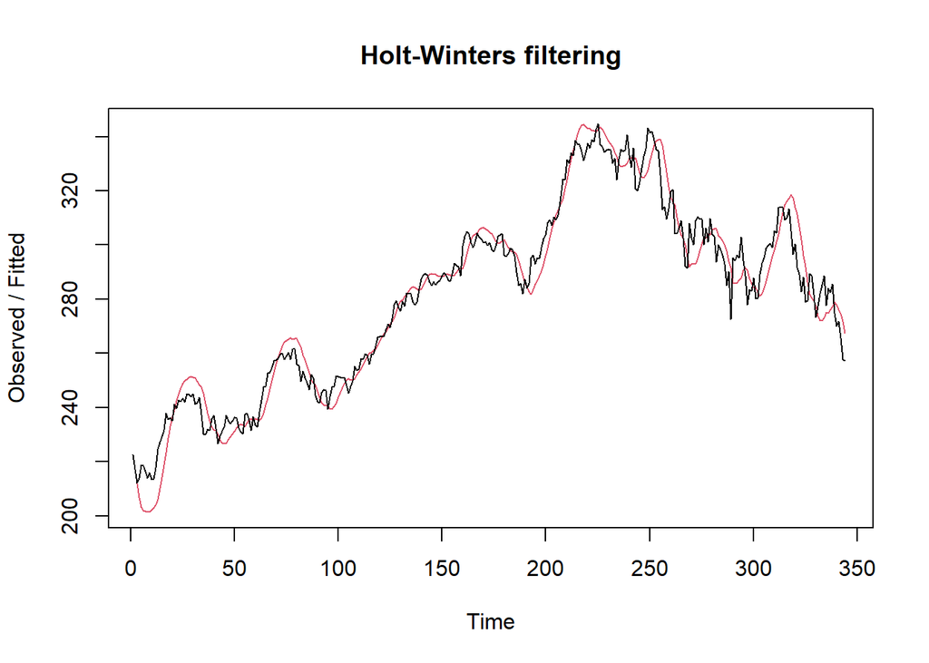

```r
#Lamda=0.2 dan gamma=0.2
des.1<- HoltWinters(train.ts, gamma = FALSE, beta = 0.2, alpha = 0.2)
plot(des.1)
```

```r
#ramalan
ramalandes1<- forecast(des.1, h=87)
ramalandes1
```

```
##     Point Forecast       Lo 80    Hi 80        Lo 95    Hi 95
## 345       263.6180 254.0961017 273.1400  249.0554990 278.1806
## 346       261.7156 251.9232494 271.5079  246.7395096 276.6916
## 347       259.8131 249.6643248 269.9619  244.2918840 275.3343
## 348       257.9106 247.3143228 268.5070  241.7049676 274.1163
## 349       256.0082 244.8711974 267.1452  238.9756312 273.0407
## 350       254.1057 242.3354566 265.8760  236.1046517 272.1068
## 351       252.2033 239.7095723 264.6970  233.0958097 271.3107
## 352       250.3008 236.9973451 263.6043  229.9549177 270.6467
## 353       248.3983 234.2033313 262.5934  226.6889438 270.1078
## 354       246.4959 231.3323894 261.6594  223.3053185 269.6865
## 355       244.5934 228.3893596 260.7975  219.8114444 269.3754
## 356       242.6910 225.3788606 260.0031  216.2143850 269.1675
## 357       240.7885 222.3051774 259.2718  212.5206936 269.0563
## 358       238.8860 219.1722124 258.5999  208.7363385 269.0358
```

[output cut: 73 more lines]

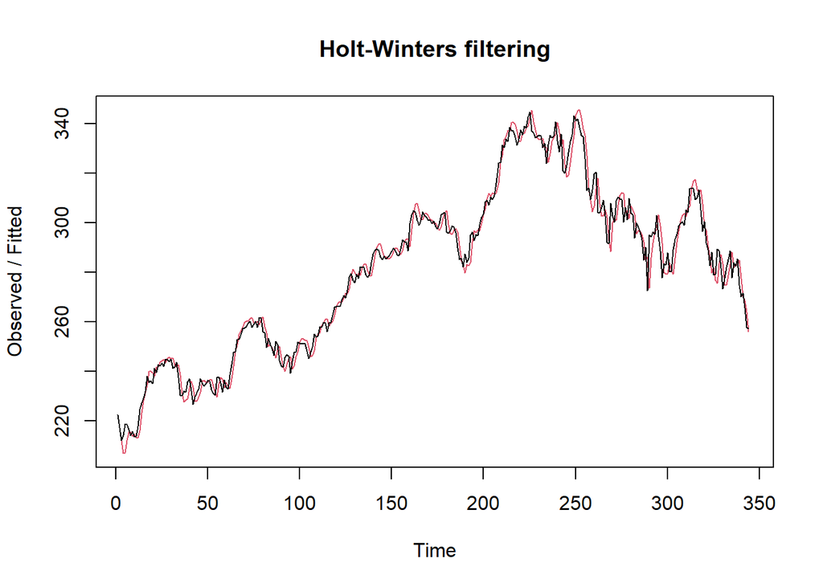

```r
#Lamda=0.6 dan gamma=0.3
des.2<- HoltWinters(train.ts, gamma = FALSE, beta = 0.3, alpha = 0.6)
plot(des.2)
```

```r
#ramalan
ramalandes2<- forecast(des.2, h=87)
ramalandes2
```

```
##     Point Forecast       Lo 80    Hi 80       Lo 95    Hi 95
## 345     252.968399  246.582017 259.3548  243.201271 262.7355
## 346     249.093227  240.993845 257.1926  236.706291 261.4802
## 347     245.218055  235.059893 255.3762  229.682487 260.7536
## 348     241.342883  228.845141 253.8406  222.229236 260.4565
## 349     237.467711  222.392604 252.5428  214.412324 260.5231
## 350     233.592539  215.731211 251.4539  206.275995 260.9091
## 351     229.717368  208.881315 250.5534  197.851375 261.5834
## 352     225.842196  201.857953 249.8264  189.161462 262.5229
## 353     221.967024  194.672732 249.2613  180.224007 263.7100
## 354     218.091852  187.334944 248.8488  171.053220 265.1305
## 355     214.216680  179.852251 248.5811  161.660820 266.7725
## 356     210.341509  172.231128 248.4519  152.056712 268.6263
## 357     206.466337  164.477153 248.4555  142.249423 270.6833
## 358     202.591165  156.595206 248.5871  132.246416 272.9359
```

[output cut: 73 more lines]

Selanjutnya jika ingin membandingkan plot data latih dan data uji adalah sebagai berikut.

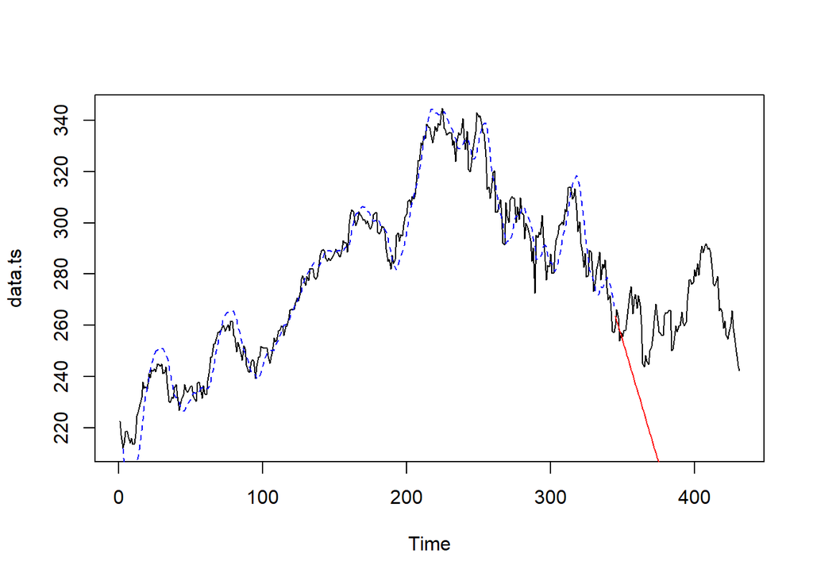

```r
#Visually evaluate the prediction
plot(data.ts)
lines(des.1$fitted[,1], lty=2, col="blue")
lines(ramalandes1$mean, col="red")
```

Untuk mendapatkan nilai parameter optimum dari DES, argumen `alpha` dan `beta` dapat dibuat `NULL` seperti berikut.

```r
#Lamda dan gamma optimum
des.opt<- HoltWinters(train.ts, gamma = FALSE)
des.opt
```

```
## Holt-Winters exponential smoothing with trend and without seasonal component.
##
## Call:
## HoltWinters(x = train.ts, gamma = FALSE)
##
## Smoothing parameters:
##  alpha: 0.8980665
##  beta : 0.07888112
##  gamma: FALSE
##
## Coefficients:
##         [,1]
## a 257.261958
## b  -1.860571
```

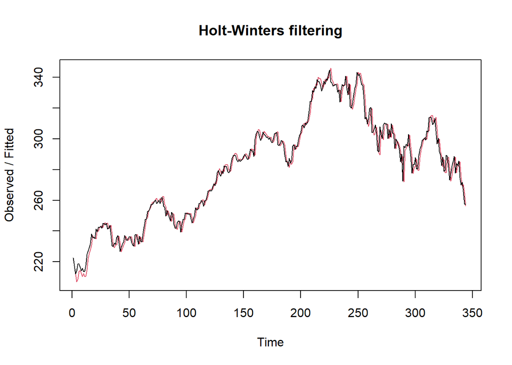

```r
plot(des.opt)
```

```r
#ramalan
ramalandesopt<- forecast(des.opt, h=87)
ramalandesopt
```

```
##     Point Forecast        Lo 80    Hi 80       Lo 95    Hi 95
## 345      255.40139  249.3575437 261.4452  246.158126 264.6446
## 346      253.54082  245.1253623 261.9563  240.670490 266.4111
## 347      251.68024  241.1774167 262.1831  235.617555 267.7429
## 348      249.81967  237.3551928 262.2842  230.756895 268.8825
## 349      247.95910  233.5942797 262.3239  225.990002 269.9282
## 350      246.09853  229.8618268 262.3352  221.266634 270.9304
## 351      244.23796  226.1388655 262.3371  216.557783 271.9181
## 352      242.37739  222.4135537 262.3412  211.845337 272.9094
## 353      240.51682  218.6780984 262.3555  207.117378 273.9163
## 354      238.65625  214.9271780 262.3853  202.365767 274.9467
## 355      236.79568  211.1570633 262.4343  197.584801 276.0066
## 356      234.93511  207.3650935 262.5051  192.770411 277.0998
## 357      233.07453  203.5493489 262.5997  187.919660 278.2294
## 358      231.21396  199.7084372 262.7195  183.030419 279.3975
```

[output cut: 73 more lines]

Selanjutnya akan dilakukan perhitungan akurasi pada data latih maupun data uji dengan ukuran akurasi SSE, MSE dan MAPE.

#### Akurasi Data Latih

```r
#Akurasi Data Training
ssedes.train1<-des.1$SSE
msedes.train1<-ssedes.train1/length(train.ts)
sisaandes1<-ramalandes1$residuals
head(sisaandes1)
```

```
## Time Series:
## Start = 1
## End = 6
## Frequency = 1
## [1]        NA        NA  0.180007  7.276804 15.433175 16.490953
```

```r
mapedes.train1 <- sum(abs(sisaandes1[3:length(train.ts)]/train.ts[3:length(train.ts)])
                      *100)/length(train.ts)

akurasides.1 <- matrix(c(ssedes.train1,msedes.train1,mapedes.train1))
row.names(akurasides.1)<- c("SSE", "MSE", "MAPE")
colnames(akurasides.1) <- c("Akurasi lamda=0.2 dan gamma=0.2")
akurasides.1
```

```
##      Akurasi lamda=0.2 dan gamma=0.2
## SSE                     18845.583866
## MSE                        54.783674
## MAPE                        2.128078
```

```r
ssedes.train2<-des.2$SSE
msedes.train2<-ssedes.train2/length(train.ts)
sisaandes2<-ramalandes2$residuals
head(sisaandes2)
```

```
## Time Series:
## Start = 1
## End = 6
## Frequency = 1
## [1]        NA        NA  0.180007  7.179601 11.457115  6.255848
```

```r
mapedes.train2 <- sum(abs(sisaandes2[3:length(train.ts)]/train.ts[3:length(train.ts)])
                      *100)/length(train.ts)

akurasides.2 <- matrix(c(ssedes.train2,msedes.train2,mapedes.train2))
row.names(akurasides.2)<- c("SSE", "MSE", "MAPE")
colnames(akurasides.2) <- c("Akurasi lamda=0.6 dan gamma=0.3")
akurasides.2
```

```
##      Akurasi lamda=0.6 dan gamma=0.3
## SSE                      8468.391449
## MSE                        24.617417
## MAPE                        1.318674
```

Hasil akurasi dari data latih didapatkan skenario 2 dengan lamda=0.6 dan gamma=0.3 memiliki hasil yang lebih baik. Namun untuk kedua skenario dapat dikategorikan peramalan sangat baik berdasarkan nilai MAPE-nya.

#### Akurasi Data Uji

```r
#Akurasi Data Testing
selisihdes1<-ramalandes1$mean-testing$Open
selisihdes1
```

```
## Time Series:
## Start = 345
## End = 431
## Frequency = 1
##  [1]    3.658036   -4.394418   -3.186893    4.010653   -1.231803   -1.384278
##  [7]   -5.686748   -7.839208  -13.871642  -21.984124  -27.936572  -32.509045
## [13]  -23.661505  -31.423951  -35.076411  -31.558888  -38.531324  -36.503792
## [19]  -31.206240  -17.638714  -18.291173  -24.643630  -24.216088  -24.838549
## [25]  -32.301007  -35.833471  -41.415939  -49.558390  -57.860843  -55.533323
## [31]  -51.045768  -52.408220  -53.650707  -55.323156  -64.815612  -68.088067
## [37]  -69.660541  -72.422986  -74.555457  -60.767914  -63.050379  -70.102833
## [43]  -76.035292  -75.767739  -79.990206  -81.782681  -89.135122  -86.797592
## [49]  -87.560037  -90.762516 -101.254972 -111.107444 -113.129899 -113.212352
## [55] -115.874822 -122.817260 -122.069725 -128.872179 -126.364666 -136.797124
## [61] -141.379577 -140.912042 -145.334491 -148.226941 -147.879401 -150.231873
## [67] -150.844325 -145.926778 -142.189253 -143.061715 -146.884158 -150.536618
## [73] -139.209097 -141.931564 -142.554026 -137.936466 -142.668943 -139.071403
## [79] -139.473848 -144.186321 -149.078771 -156.261230 -151.223687 -147.816150
## [85] -145.958615 -142.351066 -142.463532
```

```r
SSEtestingdes1<-sum(selisihdes1^2)
MSEtestingdes1<-SSEtestingdes1/length(testing$Open)
MAPEtestingdes1<-sum(abs(selisihdes1/testing$Open)*100)/length(testing$Open)

selisihdes2<-ramalandes2$mean-testing$Open
selisihdes2
```

```
## Time Series:
## Start = 345
## End = 431
## Frequency = 1
##  [1]   -6.991592  -17.016758  -17.781945  -12.557111  -19.772279  -21.897466
##  [7]  -28.172647  -32.297819  -40.302965  -50.388159  -58.313319  -64.858503
## [13]  -57.983675  -67.718833  -73.344005  -71.799194  -80.744341  -80.689521
## [19]  -77.364681  -65.769867  -68.395039  -76.720208  -78.265377  -80.860550
## [25]  -90.295720  -95.800896 -103.356076 -113.471238 -123.746403 -123.391595
## [31] -120.876752 -124.211916 -127.427114 -131.072275 -142.537443 -147.782610
## [37] -151.327796 -156.062952 -160.168135 -148.353304 -152.608481 -161.633647
## [43] -169.538818 -171.243976 -177.439155 -181.204342 -190.529495 -190.164677
## [49] -192.899833 -198.075024 -210.540192 -222.365376 -226.360543 -228.415707
## [55] -233.050889 -241.966039 -243.191217 -251.966383 -251.431581 -263.836751
## [61] -270.391916 -271.897093 -278.292254 -283.157416 -284.782587 -289.107771
## [67] -291.692935 -288.748100 -286.983287 -289.828460 -295.623615 -301.248787
## [73] -291.893978 -296.589157 -299.184330 -296.539482 -303.244671 -301.619843
## [79] -303.995000 -310.680185 -317.545346 -326.700517 -323.635686 -322.200861
## [85] -322.316038 -320.681200 -322.766378
```

```r
SSEtestingdes2<-sum(selisihdes2^2)
MSEtestingdes2<-SSEtestingdes2/length(testing$Open)
MAPEtestingdes2<-sum(abs(selisihdes2/testing$Open)*100)/length(testing$Open)

selisihdesopt<-ramalandesopt$mean-testing$Open
selisihdesopt
```

```
## Time Series:
## Start = 345
## End = 431
## Frequency = 1
##  [1]   -4.558604  -12.569169  -11.319755   -4.080320   -9.280887   -9.391473
##  [7]  -13.652054  -15.762625  -21.753170  -29.823763  -35.734322  -40.264906
## [13]  -31.375477  -39.096034  -42.706605  -39.147193  -46.077740  -44.008319
## [19]  -38.668878  -25.059463  -25.670034  -31.980603  -31.511172  -32.091744
## [25]  -39.512313  -43.002888  -48.543467  -56.644029  -64.904593  -62.535184
## [31]  -58.005740  -59.326303  -60.526901  -62.157461  -71.608028  -74.838594
## [37]  -76.369179  -79.089735  -81.180317  -67.350885  -69.591461  -76.602026
## [43]  -82.492596  -82.183154  -86.363732  -88.114318  -95.424870  -93.045451
## [49]  -93.766007  -96.926597 -107.377164 -117.187747 -119.168313 -119.208877
## [55] -121.829458 -128.730007 -127.940584 -134.701149 -132.151747 -142.542316
## [61] -147.082880 -146.573456 -150.954016 -153.804577 -153.415148 -155.725731
## [67] -156.296294 -151.336858 -147.557444 -148.388017 -152.168571 -155.779143
## [73] -144.409733 -147.090311 -147.670884 -143.011435 -147.702023 -144.062594
## [79] -144.423150 -149.093734 -153.944295 -161.084865 -156.005433 -152.556007
## [85] -150.656583 -147.007145 -147.077722
```

```r
SSEtestingdesopt<-sum(selisihdesopt^2)
MSEtestingdesopt<-SSEtestingdesopt/length(testing$Open)
MAPEtestingdesopt<-sum(abs(selisihdesopt/testing$Open)*100)/length(testing$Open)

akurasitestingdes <-
  matrix(c(SSEtestingdes1,MSEtestingdes1,MAPEtestingdes1,SSEtestingdes2,MSEtestingdes2,
           MAPEtestingdes2,SSEtestingdesopt,MSEtestingdesopt,MAPEtestingdesopt),
         nrow=3,ncol=3)
row.names(akurasitestingdes)<- c("SSE", "MSE", "MAPE")
colnames(akurasitestingdes) <- c("des ske1","des ske2","des opt")
akurasitestingdes
```

```
##          des ske1     des ske2      des opt
## SSE  841273.33680 3.670334e+06 928727.01297
## MSE    9669.80847 4.218775e+04  10675.02314
## MAPE     31.17251 6.698936e+01     33.53241
```

#### Perbandingan SES dan DES

```r
MSEfull <-
  matrix(c(MSEtesting1,MSEtesting2,MSEtestingopt,MSEtestingdes1,MSEtestingdes2,
           MSEtestingdesopt),nrow=3,ncol=2)
row.names(MSEfull)<- c("ske 1", "ske 2", "ske opt")
colnames(MSEfull) <- c("ses","des")
MSEfull
```

```
##              ses       des
## ske 1   7281.308  9669.808
## ske 2   8680.732 42187.748
## ske opt 9233.608 10675.023
```

Kedua metode dapat dibandingkan dengan menggunakan ukuran akurasi yang sama. Contoh di atas adalah perbandingan kedua metode dengan ukuran akurasi MSE. Hasilnya didapatkan metode SES lebih baik dibandingkan metode DES dilihat dari MSE yang lebih kecil nilainya.